# Bonytail (GIEL) Off-Channel Model: Data Support for the Proposed IPM Critique

Figures illustrating data limitations referenced in the critique of the proposed Bonytail integrated population model

## Purpose

`documents/Bonytail Model Critique.docx` compiles an assessment (this assistant plus a supporting AI) of the externally-proposed Bonytail integrated population model (Sound Science LLC, draft 10 July 2026) against our own GIEL joint robust-design model results and the Lake Havasu open-water telemetry precedent. That document is text-only. This report adds figures built from data and model results already on hand — the completed GIEL-only fit (`data/BWRobustDesign_MCMC_giel.RData`), the underlying PIT-scan and netting records (`data/ReportingData.RData`), the recorded die-off windows (`data/BWDieOffEvents.csv`), and a scratch recruit-density build (`data/GIEL_scratch_data.RData`) from the 2026-09-10 GIEL structure assessment — to illustrate, rather than just assert, where the current data support a simpler model than the one proposed. **No new model fitting was performed for this report**; every figure below is derived from existing fits or directly from the raw monitoring data.

See `model/BONY_ProposedIPM_Critique.md` for the full structural critique this report supports, and `documents/BONY_Proposed_IPM_Summary.md` for a neutral summary of the proposed IPM itself.

## 1. Where the proposed IPM aligns with the data: ponds sustain fish, open water does not

[figure not shown]

## 2. Where the proposed IPM’s complexity outruns the data

### 2a. Stage structure: the data support one size break, not three or four

The proposed IPM carries multiple early wild sub-stages (S1-2, S2-4, S3-4, S4-4), an architecture that mirrors the three-stage density-dependent model built for razorback sucker at Yuma Cove. For bonytail, re-sighting of netting-tagged juveniles (n = 1,438, IP2/IP5/IP6, 2017-2024) shows a single break, at the pond model’s existing 250 mm stage threshold — not a second break near 350 mm as in the razorback sucker model.

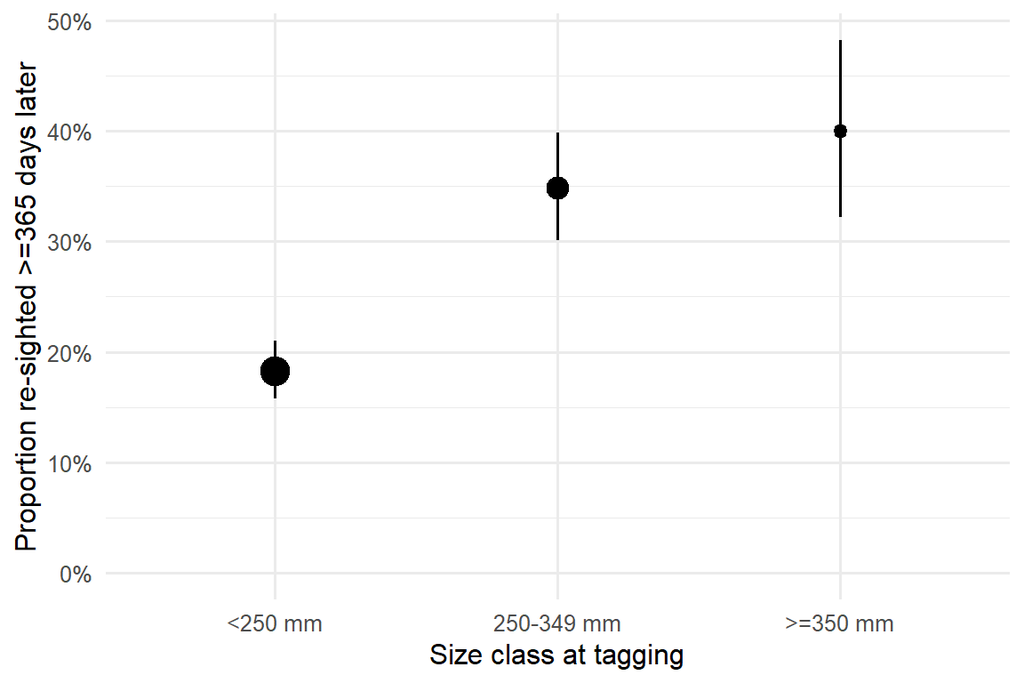

Figure 2: Proportion of netting-tagged bonytail juveniles re-sighted >=365 days later, by size class at tagging (n = 1,438). Error bars are 95% Wilson confidence intervals; point size scales with sample size.

Both the 250-349 mm and >=350 mm classes clearly out-survive the <250 mm class, but a logistic model controlling for stocking/tagging-cohort year (FY) finds no difference between them (log-odds difference = 0.13 +/- 0.21, z = 0.64, p = 0.52). A three- or four-stage architecture built around finer size distinctions above 250 mm is not identifiable from this re-sighting pattern.

### 2b. Covariate complexity vs. data sufficiency

Two separate lines of evidence argue against adding covariate slopes (environmental, density, or otherwise) to bonytail survival right now: recruitment is too sparse and skewed to fit a density-dependent term, and even the pond-seasons without any density signal show wide, unpatterned swings in survival that a shared covariate slope would need to explain.

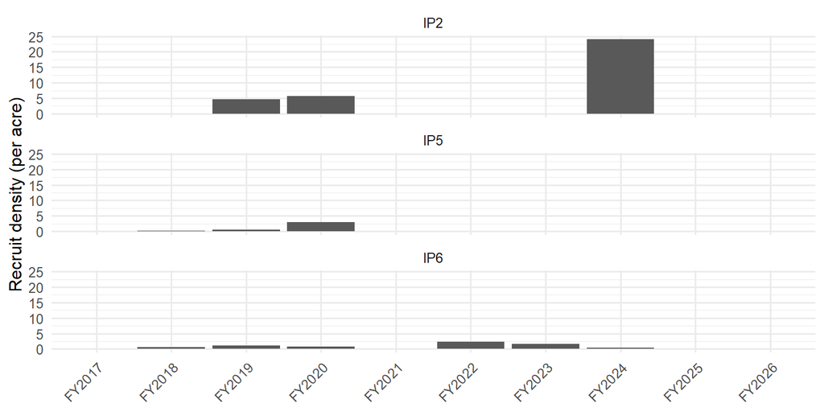

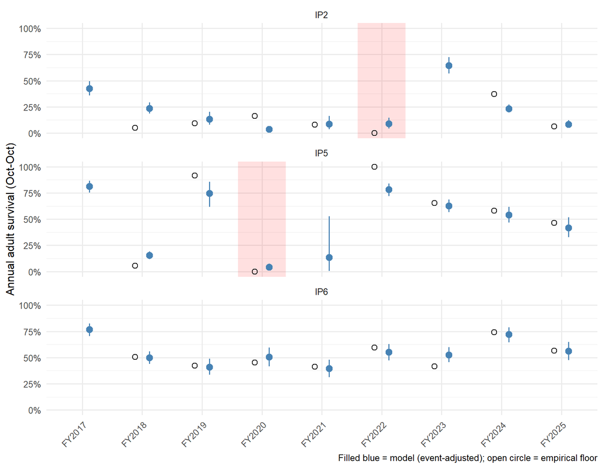

Figure 4: Empirical annual adult survival floor (fraction of adults known alive at one October census re-sighted after the next; open circles) vs. the fitted joint robust-design model’s event-adjusted realized annual survival (filled points with 95% credible interval). Red shading marks the two confirmed die-off pond-seasons (IP5 FY2020, IP2 FY2022).

### 2c. Origin-based survival: architecture, not sample size, is the current limit

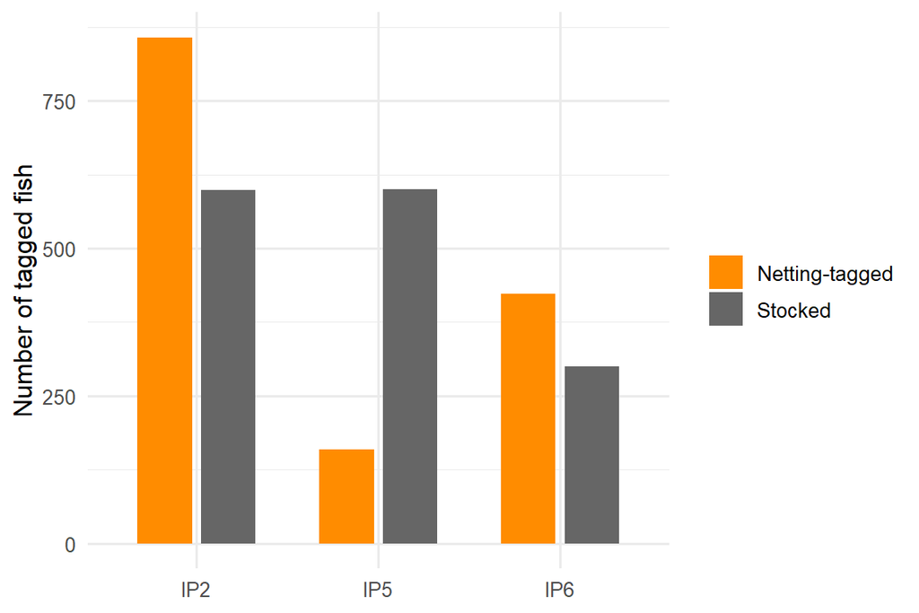

Figure 5: Sample size of tagged bonytail by origin and pond. ‘Netting-tagged’ fish (origin = tagged at a subsequent netting event, the closest available proxy for recruited/wild-hatched fish) are common at all three ponds.

Sample sizes for a stocked-vs-wild survival contrast are not the limiting factor (IP2: 857 netting-tagged vs. 599 stocked; IP5: 159 vs. 600; IP6: 423 vs. 300). What is missing is the model term itself: the fitted joint robust-design model only lets `origin` affect a temporary post-release survival offset (`b_post`, active for a few months after tagging); established adult survival (`lphiA`) has no origin split at all. The proposed IPM’s stocked-vs-wild split on established survival is conceptually reasonable and the raw sample sizes could support a first attempt, but it requires a model extension we have not yet built, and — given how thin and event-dominated the non-crash seasons already are (§2b) — any such split should be checked for robustness rather than assumed informative.

## 3. Summary comparison

| Aspect | Your GIEL OCH model | Proposed BONY IPM (OCH component) | What Havasu shows |
| --- | --- | --- | --- |
| Stage structure | 2 stages (<=250 mm, >250 mm); single size break, confirmed by re-sighting (Fig. 2) | 4 stages with early wild sub-stages (S1-2, S2-4, S3-4, S4-4) | Telemetry + PIT could not identify a bare survival curve |
| Density effects | No density-dependent survival/growth; recruit density near-zero in most pond-seasons (Fig. 3) | Environmental covariates on phi^4 and F; implicitly assumes smooth gradients | Survival near-zero in open water; mortality is a ceiling, not a gradient |
| Die-offs | Explicit dE event terms with dated windows; partial-season windows under-correct (Fig. 4) | 2020/2022 IPCA die-offs treated as year random-effect shocks, operational not environmental | Catastrophic, rapid losses; no environmental covariate successfully modeled |
| Covariates (general) | None yet on survival; empirical floors swing widely with no smooth pattern (Fig. 4) | Environmental (DO, temp, water level) on phi^4/F; release/habitat on phi^3; shared slopes across ponds | Attempted CJS/Barker with time-varying survival/detection failed - parameters nearly 0 to 1 |
| Origin split (stocked vs. wild) | Not implemented on established survival; sample sizes sufficient but architecture missing (Fig. 5) | Explicit origin-based survival split by pond for phi^4 | Open water: almost no long-term survivors; origin contrasts likely swamped by predation |

## 4. Bottom line

The figures above show, rather than assert, why the proposed IPM’s stage structure, covariate stack, and origin split are ahead of what current GIEL data can identify: a single, well-supported size break; recruit density that is zero in most pond-seasons with one extreme outlier; empirical survival that swings widely between “clean” pond-seasons with no discernible pattern; a die-off mechanism that works well only when its window spans most of a season; and an origin split that is conceptually sound but not yet built into the fitted model. None of this required a new model run — all of it comes from the completed GIEL-only fit and the underlying monitoring records. The existing 2-stage joint robust-design model, with explicit dated die-off terms, remains the better match to what the data currently support; the highest-value next steps are pond-specific (e.g., checking IP2 for additional unflagged mortality) rather than adding covariate layers.